# 5. ARMA Models

# (5-5) Box-Cox Power Transformation

[Nao Mimoto](https://nmimoto.github.io/) - [Dept. of Statistics](http://www.uakron.edu/stat/) : [The University of Akron](http://www.uakron.edu)

[TS Class Web Page](https://nmimoto.github.io/477/) – [R resource page](https://nmimoto.github.io/R/)

# 1. Power Transformation

Cryer p101

- generalization of taking a log of a time series.

  $${\large
  f_{\lambda}(x) =
  \left\{
  \begin{array}{ll}
  \frac{x^\lambda-1}{\lambda} & \mbox{ if } \lambda \ne 0\\\\
  ln(x) & \mbox{ if } \lambda=0 \\
  \end{array} \right.
  }$$
  usually $-1<\lambda<2$.
- One can show
  $$\frac{x^\lambda - 1}{\lambda} \to \log(x) \hspace{10mm} \mbox{ as } \lambda \to 0.$$
- Sometimes called Normalizing Transformation
- This transformation is for positive data only.
- If data has negative observations, add a constant.
- You can try $\pm 1, \pm1/2, \pm 1/3, \pm 1/4, 0$ and see if it helps.

# 2. Copper Data

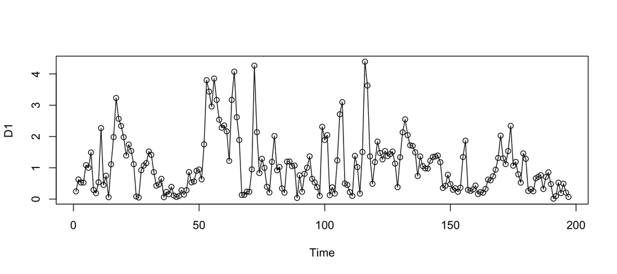

```r
  D  <- read.csv("https://nmimoto.github.io/datasets/copper.csv")
  D1 <- ts(D[,2], start=1)    #- extract only second column as time series
  plot(D1, type="o")
```

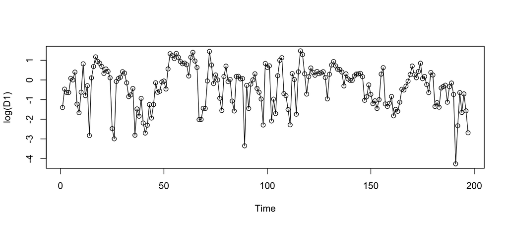

```r
  library(forecast)
  source('https://nmimoto.github.io/R/TS-00.txt')

  #   ?Arima    # open help page for Arima()


  #- plot log of price
  plot(log(D1), type="o")
```

```r
  #- estimate the best lambda to use
  BoxCox.lambda(D1)
```

```
## [1] 0.2283439
```

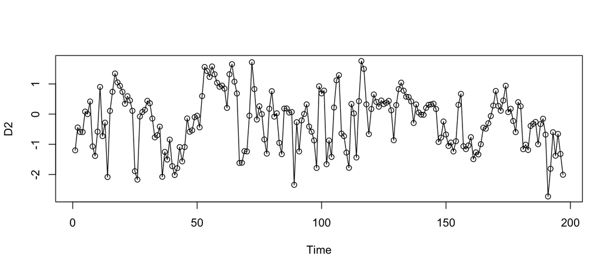

```r
  D2 <- BoxCox(D1, .228)
  plot(D2, type="o")
```

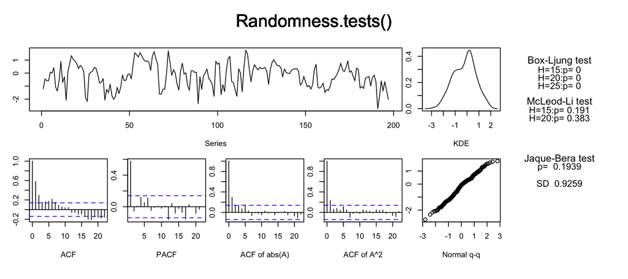

```
##   B-L test H0: the series is uncorrelated
##   M-L test H0: the square of the series is uncorrelated
##   J-B test H0: the series came from Normal distribution
##   SD         : Standard Deviation of the series
```

```
##      BL15 BL20 BL25  ML15  ML20    JB    SD
## [1,]    0    0    0 0.191 0.383 0.194 0.926
```

```r
  Randomness.tests(D2)
```

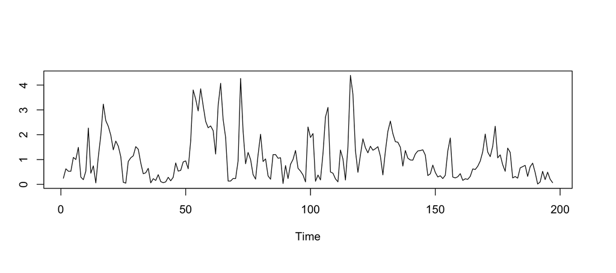

```r
  X <- InvBoxCox(D2, .228)    #- to transform BACK
  plot(X)
```

## a) Transform by hand

```r
  # Transform outside of auto.arima
  D2 <- BoxCox(D1, .228)

  auto.arima(D2, stepwise=FALSE, approximation=FALSE)
```

```
## Series: D2
## ARIMA(1,0,0) with non-zero mean
##
## Coefficients:
##          ar1     mean
##       0.5883  -0.2406
## s.e.  0.0582   0.1289
##
## sigma^2 estimated as 0.5679:  log likelihood=-223
## AIC=452   AICc=452.12   BIC=461.85
```

```r
  Fit01 <- Arima(D2, order=c(1,0,0), include.mean=FALSE)
  Fit01
```

```
## Series: D2
## ARIMA(1,0,0) with zero mean
##
## Coefficients:
##          ar1
##       0.6115
## s.e.  0.0572
##
## sigma^2 estimated as 0.5744:  log likelihood=-224.65
## AIC=453.29   AICc=453.36   BIC=459.86
```

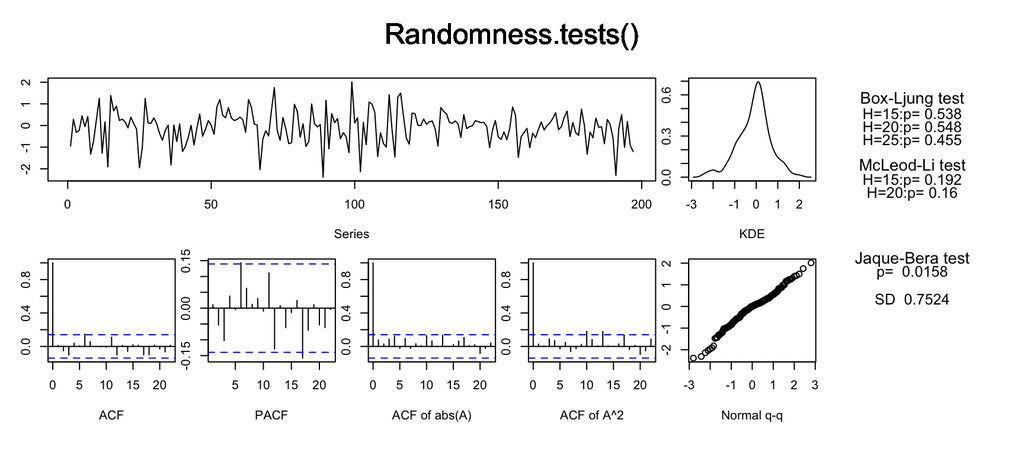

```
##   B-L test H0: the series is uncorrelated
##   M-L test H0: the square of the series is uncorrelated
##   J-B test H0: the series came from Normal distribution
##   SD         : Standard Deviation of the series
```

```
##       BL15  BL20  BL25  ML15 ML20    JB    SD
## [1,] 0.538 0.548 0.455 0.192 0.16 0.016 0.752
```

```r
  Randomness.tests(Fit01$resid)
```

```r
  forecast(Fit01, 10)
```

```
##     Point Forecast     Lo 80      Hi 80     Lo 95     Hi 95
## 198    -1.22903892 -2.200290 -0.2577876 -2.714440 0.2563619
## 199    -0.75158680 -1.890050  0.3868763 -2.492716 0.9895422
## 200    -0.45961337 -1.654611  0.7353846 -2.287205 1.3679783
## 201    -0.28106461 -1.496529  0.9343999 -2.139957 1.5778279
## 202    -0.17187776 -1.394908  1.0511524 -2.042341 1.6985855
## 203    -0.10510738 -1.330955  1.1207401 -1.979879 1.7696646
## 204    -0.06427568 -1.291175  1.1626237 -1.940656 1.8121050
## 205    -0.03930612 -1.266599  1.1879864 -1.916288 1.8376758
## 206    -0.02403664 -1.251476  1.2034029 -1.901243 1.8531701
## 207    -0.01469898 -1.242193  1.2127955 -1.891990 1.8625918
```

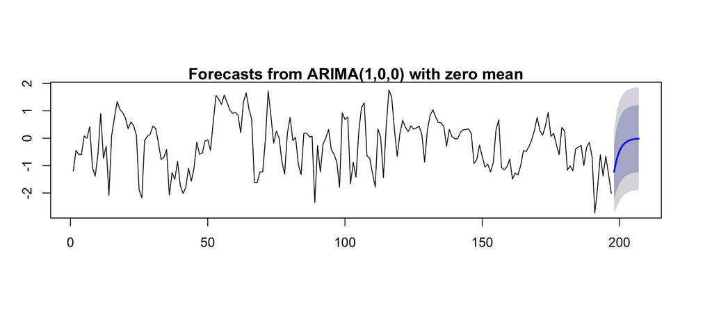

```r
  plot(forecast(Fit01, 10))
```

- Then we would have to transform back by hand.
- it’s much better to do this automatically.

## b) Transform inside auto.arima()

- If we use lambda= option inside auto.arima(), then forecast will be automatically transformed back into original space.

```r
  #- Use Lambda on D1
  auto.arima(D1, lambda=.228, stepwise=FALSE, approximation=FALSE)
```

```
## Series: D1
## ARIMA(1,0,0) with non-zero mean
## Box Cox transformation: lambda= 0.228
##
## Coefficients:
##          ar1     mean
##       0.5883  -0.2406
## s.e.  0.0582   0.1289
##
## sigma^2 estimated as 0.5679:  log likelihood=-223
## AIC=452   AICc=452.12   BIC=461.85
```

```r
  Fit02 <- Arima(D1, order=c(1,0,0), lambda=.228, include.mean=FALSE)
  Fit02
```

```
## Series: D1
## ARIMA(1,0,0) with zero mean
## Box Cox transformation: lambda= 0.228
##
## Coefficients:
##          ar1
##       0.6115
## s.e.  0.0572
##
## sigma^2 estimated as 0.5744:  log likelihood=-224.65
## AIC=453.29   AICc=453.36   BIC=459.86
```

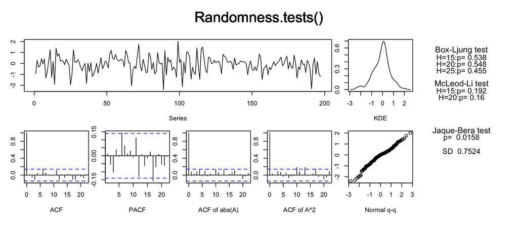

```
##   B-L test H0: the series is uncorrelated
##   M-L test H0: the square of the series is uncorrelated
##   J-B test H0: the series came from Normal distribution
##   SD         : Standard Deviation of the series
```

```
##       BL15  BL20  BL25  ML15 ML20    JB    SD
## [1,] 0.538 0.548 0.455 0.192 0.16 0.016 0.752
```

```r
  Randomness.tests(Fit02$resid)
```

```r
  forecast(Fit02, 10)
```

```
##     Point Forecast      Lo 80     Hi 80      Lo 95    Hi 95
## 198      0.2364182 0.04713407 0.7666891 0.01453752 1.282934
## 199      0.4384818 0.08436469 1.4488279 0.02510431 2.440725
## 200      0.6153759 0.12527460 1.9736036 0.03944955 3.289327
## 201      0.7479086 0.16033733 2.3328044 0.05311317 3.848925
## 202      0.8391748 0.18658431 2.5658196 0.06400887 4.202652
## 203      0.8990764 0.20472609 2.7130030 0.07183593 4.422279
## 204      0.9373005 0.21667851 2.8046794 0.07711566 4.557575
## 205      0.9612860 0.22432751 2.8613452 0.08054352 4.640621
## 206      0.9761854 0.22913666 2.8962183 0.08271780 4.691508
## 207      0.9853842 0.23212785 2.9176253 0.08407748 4.722660
```

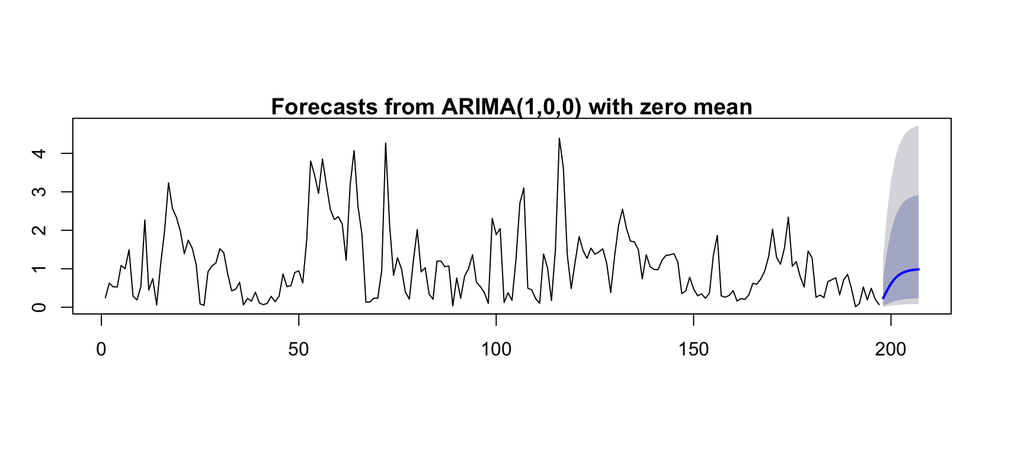

```r
  plot(forecast(Fit02, 10))
```

### Rolling 1-step forecast

```r
 #--- Rolling 1-step Prediction w/ fixed window
  library(forecast)
  Y <- D1                  # Entire data
  window.size <- 150       # Window size for estimation
  order.in <- c(1,0,0)     # model order
  include_mean <- FALSE    #
  this_lambda <- 0.228

    Yhat  <- Yhat.CIu <- Yhat.CIl <- 0        # initialize what needs to be saved
    for (i in 1:(length(Y)-window.size)) {

      # Force to fit the model
      Fit00 <- Arima( Y[i:(i+window.size-1)], order=order.in, include.mean=include_mean, lambda=this_lambda)

      Y.h  <- forecast(Fit00, 1)       # one step prediction
      Yhat[i]     <- Y.h$mean
      Yhat.CIu[i] <- Y.h$upper[2]
      Yhat.CIl[i] <- Y.h$lower[2]
    }

    # Yhat starts at window.size+1 up to length(Y)
    Yhat     = ts(Yhat,     start=time(Y)[window.size+1], freq=frequency(Y))
    Yhat.CIu = ts(Yhat.CIu, start=time(Y)[window.size+1], freq=frequency(Y))
    Yhat.CIl = ts(Yhat.CIl, start=time(Y)[window.size+1], freq=frequency(Y))
    Y1 = window(Y, end=time(Y)[window.size],     freq=frequency(Y))
    Y2 = window(Y, start=time(Y)[window.size+1], freq=frequency(Y))

    #- Calculate prediction performance
    Pred.error = Y2 - Yhat
    Pred.rMSE =  sqrt(  mean( (Pred.error)^2 ) )     # prediction root Mean Squared Error
    c( mean(Pred.error), Pred.rMSE )                 # Av Pred Error, and pred rMSE
```

```
## [1] -0.08001851  0.44158305
```

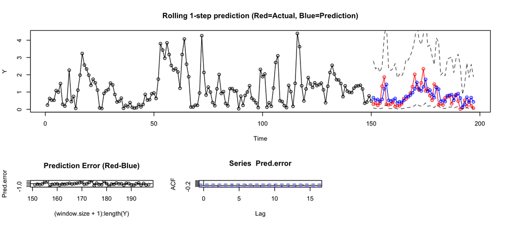

```r
  #- Plot the prediction result with original data
  layout(matrix(c(1,1,1,1,1,1,2,3,4), 3, 3, byrow=TRUE))    # 3 plots at once

  plot(  Y,  type="n", main="Rolling 1-step prediction (Red=Actual, Blue=Prediction)" )
  lines( Y1, type="o")
  lines( Y2,       type="o", col="red")
  lines( Yhat,     type="o", col="blue")
  lines( Yhat.CIu, type="l", col="gray30", lty=2)
  lines( Yhat.CIl, type="l", col="gray30", lty=2)


  # - Plot the prediction error
  plot( (window.size+1):length(Y), Pred.error, type="o", main="Prediction Error (Red-Blue)" )
  abline(h=0, lty=2)
  acf(Pred.error)
  layout(1)                    # reset the layout
```

# 3. Problem of Transforming $\sigma$

### Transforming back the forecast

```r
  # forecast in Trandformed space
  Pred1 <- forecast(Fit01, 10)
  Pred1
```

```
##     Point Forecast     Lo 80      Hi 80     Lo 95     Hi 95
## 198    -1.22903892 -2.200290 -0.2577876 -2.714440 0.2563619
## 199    -0.75158680 -1.890050  0.3868763 -2.492716 0.9895422
## 200    -0.45961337 -1.654611  0.7353846 -2.287205 1.3679783
## 201    -0.28106461 -1.496529  0.9343999 -2.139957 1.5778279
## 202    -0.17187776 -1.394908  1.0511524 -2.042341 1.6985855
## 203    -0.10510738 -1.330955  1.1207401 -1.979879 1.7696646
## 204    -0.06427568 -1.291175  1.1626237 -1.940656 1.8121050
## 205    -0.03930612 -1.266599  1.1879864 -1.916288 1.8376758
## 206    -0.02403664 -1.251476  1.2034029 -1.901243 1.8531701
## 207    -0.01469898 -1.242193  1.2127955 -1.891990 1.8625918
```

```r
  # forecast in Original space (by auto.arima)
  Pred2 <- forecast(Fit02, 10)
  Pred2
```

```
##     Point Forecast      Lo 80     Hi 80      Lo 95    Hi 95
## 198      0.2364182 0.04713407 0.7666891 0.01453752 1.282934
## 199      0.4384818 0.08436469 1.4488279 0.02510431 2.440725
## 200      0.6153759 0.12527460 1.9736036 0.03944955 3.289327
## 201      0.7479086 0.16033733 2.3328044 0.05311317 3.848925
## 202      0.8391748 0.18658431 2.5658196 0.06400887 4.202652
## 203      0.8990764 0.20472609 2.7130030 0.07183593 4.422279
## 204      0.9373005 0.21667851 2.8046794 0.07711566 4.557575
## 205      0.9612860 0.22432751 2.8613452 0.08054352 4.640621
## 206      0.9761854 0.22913666 2.8962183 0.08271780 4.691508
## 207      0.9853842 0.23212785 2.9176253 0.08407748 4.722660
```

```r
  InvBoxCox(Pred1$mean, .228)  # same forecast as Pred2
```

```
## Time Series:
## Start = 198
## End = 207
## Frequency = 1
##  [1] 0.2364182 0.4384818 0.6153759 0.7479086 0.8391748 0.8990764 0.9373005 0.9612860 0.9761854
## [10] 0.9853842
```

- no problem here.

### Problem transforming SD

```r
  Fit02
```

```
## Series: D1
## ARIMA(1,0,0) with zero mean
## Box Cox transformation: lambda= 0.228
##
## Coefficients:
##          ar1
##       0.6115
## s.e.  0.0572
##
## sigma^2 estimated as 0.5744:  log likelihood=-224.65
## AIC=453.29   AICc=453.36   BIC=459.86
```

```r
  sqrt(Fit02$sigma2)           # theoretical rMSE
```

```
## [1] 0.7578715
```

```r
  InvBoxCox(sqrt(Fit02$sigma2), .228)
```

```
## [1] 2.011895
```

### How to solve the problem

```r
  # How to solve the problem
  Y = rnorm(10000, 0, 0.7578715)
  sd(Y)
```

```
## [1] 0.7464299
```

```r
  X = InvBoxCox(Y, lambda=.228)
  sd(X)
```

```
## [1] 0.8911051
```

- we’re using 0 for the mean of $Y$, because the mean term was not significant in Fit02.
- If mean is different, the transformed back SD will be different!

```r
  # How to solve the problem
  Y = rnorm(10000, 3, 0.7578715)
  sd(Y)
```

```
## [1] 0.7544833
```

```r
  X = InvBoxCox(Y, lambda=.228)
  sd(X)
```

```
## [1] 4.691792
```

# Summary

#### Box-Cox is a generalization of log that tries to maximize the normality of the data.

#### Does not make sense to apply to series with trend

#### Normality is not a concern in model estimation.

#### Log (lambda=0) is the most useful transformation.

[TS Class Web Page](https://nmimoto.github.io/477/) – [R resource page](https://nmimoto.github.io/R/)